# COVID-19 Regional Models for Colorado

02/03/2021

**Prepared by the Colorado COVID-19 Modeling Group**  
Colorado School of Public Health: Andrea Buchwald, Elizabeth Carlton, Debashis Ghosh, Irina Kasarskis, Jonathan Samet, Laura Timm, Emily Wu; University of Colorado School of Medicine: Kathryn Colborn; University of Colorado-Boulder Department of Applied Mathematics: Sabina Altus, David Bortz; University of Colorado-Denver: jimi adams; Colorado State University: Jude Bayham

For Contact: Jon.Samet@CUAnschutz.edu

### **Summary**

Key messages in this report are:

- COVID-19 hospitalizations and estimated new infections are decreasing in 9 regions, and increasing in 2 of 11 LPHA regions.
- Infections are estimated to be increasing in the Central Mountains and West Central Partnership regions.
- We estimate more than 1 in 100 people are infectious in South Central, Southeast and West Central Partnership Regions. Contacts are particularly risk in these regions. These estimates are for January 25th.
- The estimated effective reproductive number varies significantly by region. Most indicate declining infections. Due to lags between infection and hospitalization, these estimates capture transmission through approximately January 12th.
- Lags in reporting COVID-19 hospitalizations may be contributing to apparent steep declines in hospitalizations in some regions, leading to an artificially low estimated effective reproductive number. In the Central, East Central, San Luis Valley and Southwest LPHA regions, the estimated reproductive number has declined dramatically this week compared to last week. This may be due to lags in reporting hospital data.

### **Introduction**

This report provides the results of epidemic models for regions of Colorado, using methods similar to that used for the state-level model. Estimates are presented for the 11 Local Public Health Agencies (LPHAs) regions in the state and for 8 selected counties with populations that are sufficiently large to allow for county-level estimates. The model results are subject to greater uncertainty than those for the entire state because there are fewer hospitalizations and cases in each region than in the state as a whole. Estimates are most uncertain for the regions with the smallest population size. We use the model as well as COVID-19 hospital and case data to generate three measures for each region. These measures can be used to gauge the current state of SARS-CoV-2 in each region.

- *The effective reproduction number (Re)* is a measure of how rapidly infections are spreading or declining in a region.
- *Infection prevalence* is an estimate of the portion of the population currently infected and capable of spreading infections. It can be used to gauge how risky contacts are.
- *Percent of population recovered from infection to date* is an approximation of the proportion of the population immune to SARS-CoV-2. As the immune population grows, due to immunity or infection, the spread of infection slows. We still do not know how long immunity lasts after infections with SARS-CoV-2.

**Table 1.** The estimated effective reproductive number, prevalence of infections and the percent of the population recovered to date by region. These metrics are estimated using hospitalization data from the Colorado COVID Patient Hospitalization Surveillance (COPHS) through 01/25/2021. In regions with smaller populations, reported cases are also used to generate these estimates.

|  | Are infections increasing or decreasing? Re | Are infections increasing or decreasing? Infections are… | How many people are infectious? Prevalence per 100,000 | How many people are infectious? People infectious | How many people have been infected to date? Cumulative Infections to Date | How many people have been infected to date? Proportion of population infected to date |
| --- | --- | --- | --- | --- | --- | --- |
| **LPHA Regions** |  |  |  |  |  |  |
| Central | 0.5 | Decreasing | 301 | 1 in 332 | 126,000 | 15.5 |
| Central Mountains | 1.2 | Increasing | 617 | 1 in 162 | 19,700 | 10.8 |
| East Central | 0.3 | Decreasing | 958 | 1 in 104 | 21,700 | 50.4 |
| Metro | 0.8 | Decreasing | 609 | 1 in 164 | 758,000 | 23.0 |
| Northeast | 0.9 | Decreasing | 866 | 1 in 115 | 206,000 | 26.9 |
| Northwest | 0.6 | Decreasing | 614 | 1 in 163 | 32,700 | 16.1 |
| San Luis Valley | 0.7 | Decreasing | 599 | 1 in 167 | 7,990 | 17.2 |
| South Central | 0.7 | Decreasing | 1,214 | 1 in 82 | 82,300 | 33.8 |
| Southeast | 0.9 | Decreasing | 2,033 | 1 in 49 | 17,600 | 37.6 |
| Southwest | 0.4 | Decreasing | 349 | 1 in 287 | 12,600 | 12.4 |
| West Central Partnership | 1.4 | Increasing | 1,119 | 1 in 89 | 11,200 | 10.5 |
| **Eight select counties** |  |  |  |  |  |  |
| Adams | 0.6 | Decreasing | 743 | 1 in 135 | 193,000 | 36.6 |
| Arapahoe | 0.8 | Decreasing | 864 | 1 in 116 | 180,000 | 27.0 |
| Boulder | 0.4 | Decreasing | 256 | 1 in 391 | 44,100 | 13.3 |
| Broomfield | 0.8 | Decreasing | 347 | 1 in 288 | 8,490 | 11.7 |
| Denver | 0.8 | Decreasing | 931 | 1 in 107 | 253,000 | 34.3 |
| Douglas | 0.9 | Decreasing | 626 | 1 in 160 | 43,900 | 12.4 |
| El Paso | 0.4 | Decreasing | 304 | 1 in 329 | 127,000 | 17.2 |
| Jefferson plus | 0.4 | Decreasing | 197 | 1 in 508 | 68,000 | 11.3 |

Due to the small population sizes of Gilpin and Clear Creek counties, these counties are combined with Jefferson County. Jefferson County comprises 97% of the population in the Jefferson plus county cluster.  
Due to lags between infection and hospitalization, the estimated effective reproductive number (Re) reflects the spread of infections approximately two weeks prior to the data of the last observed hospitalization.

### **Effective Reproductive Number**

The figure below shows the estimated effective reproductive number for each region since March.

The effective reproduction number (Re) is a measure of how rapidly infections are spreading or declining in a region at a given point in time. When the effective reproductive number is below 1, infections are decreasing. When the effective reproductive number is above 1, infections are increasing.

The effective reproductive number is estimated using our age-structured SEIR model fit to hospitalization data. In the four LPHA regions with smaller populations, reported SARS-CoV-2 case data are also used (San Luis Valley, Southeast, Southwest, and West Central Partnership). Because we base our parameter estimates primarily on COVID-19 hospitalization data, and hospitalizations today generally reflect infections occurring approximately 13 days prior, our most recent estimates of the effective reproductive number likely reflect the spread of infections occurring on approximately 01/12/2021.

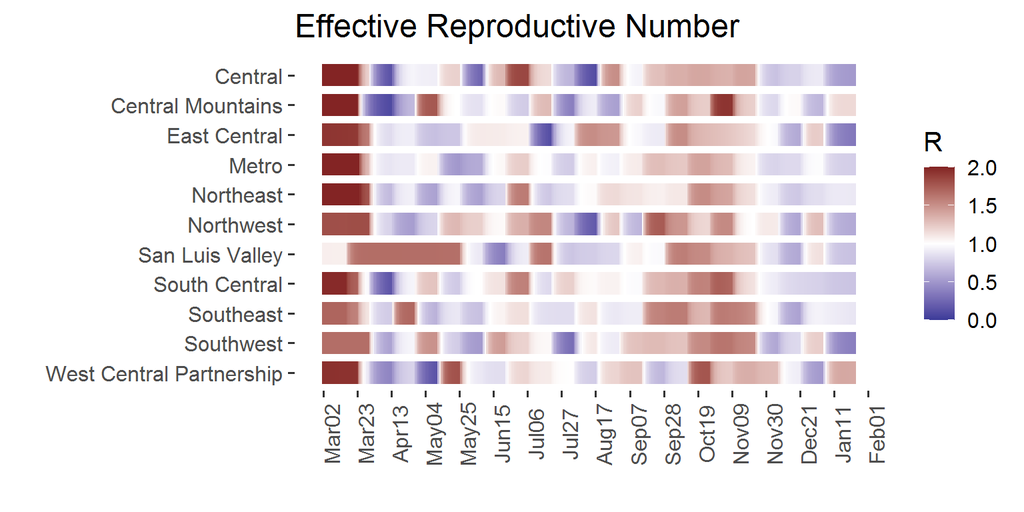

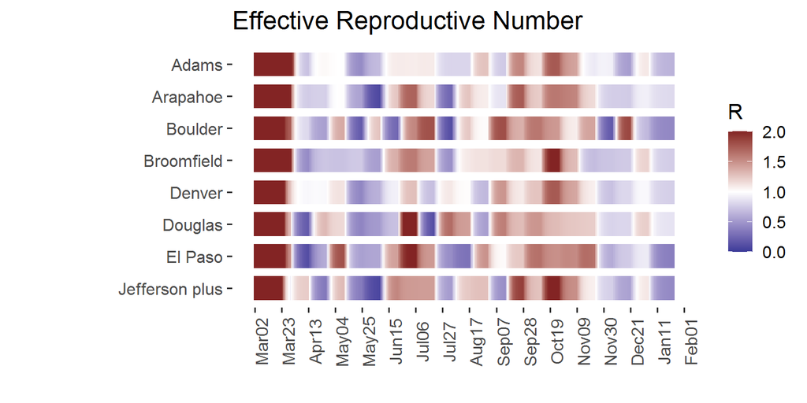

**Figure 1.** The estimated effective reproductive number (Re) over time in the 11 LPHA regions in Colorado, and 8 selected counties and county clusters. Estimates shown using COVID-19 hospitalization data through 01/25/2021.

### **Infection prevalence**

Infection prevalence provides an estimate of the proportion of the population that is currently infected with SARS-CoV-2 and capable of spreading infections. At higher levels of infection prevalence, individuals are more likely to encounter infectious individuals among their contacts. Because many people experience no symptoms or mild symptoms of COVID-19, many infections are not identified by surveillance systems. The estimates we present here are intended to provide an approximation of all infections, including those not detected by the Colorado Electronic Disease Reporting System (CEDRS).

The figure below shows the estimated infection prevalence per 100,000 individuals for each region. These are estimated from SEIR models fit separately to each area’s reported data.

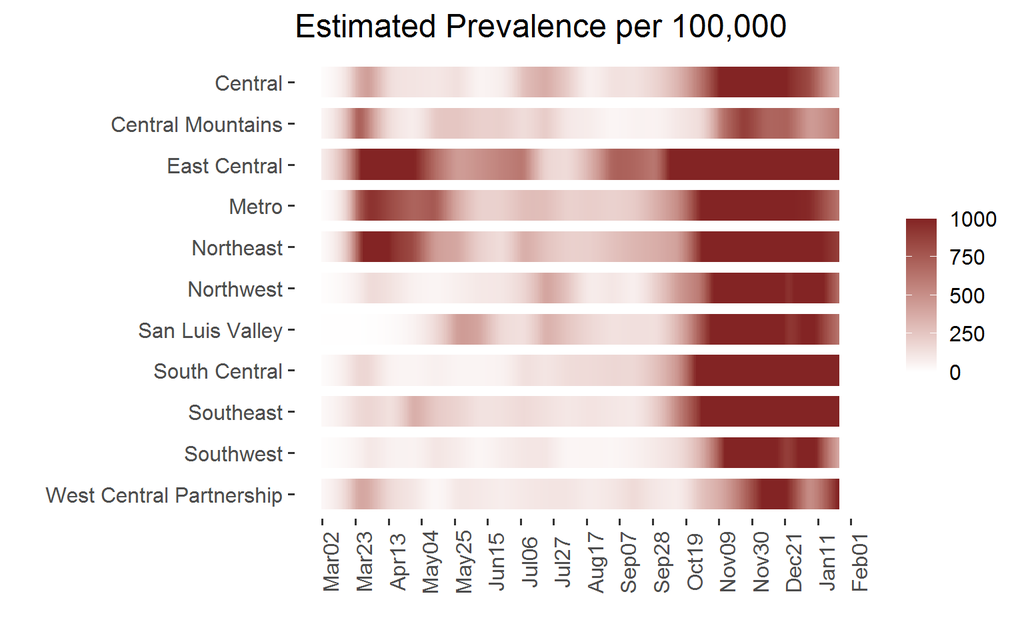

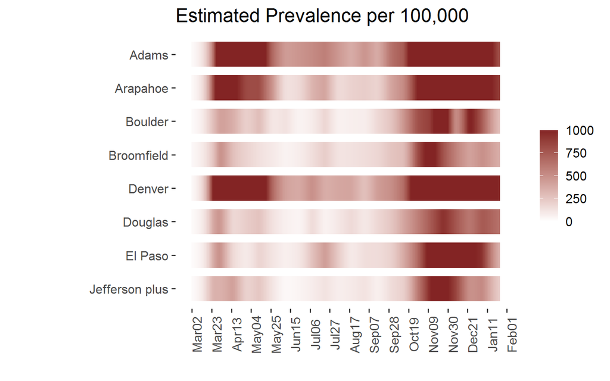

**Figure 2.** Estimated prevalence per 100,000 population for each of the 11 LPHA regions (top), plus the 8 selected counties and county clusters (bottom). All prevalence values over 1,000 per 100,000 are shown in dark red. Prevalence values estimated up to 01/25/2021.

### **The percent of the population recovered from infections to date**

As more people develop immunity, due to vaccination or prior infection, the spread of infections slows because infectious individuals are less likely to encounter individuals that are not immune. At present, immunity to SARS-CoV-2 is incompletely understood and a vaccine is not yet available.

The figure below shows model-generated estimates of the percent of the population that has been infected and is now recovered to date for each region. This provides an estimate of the percent of the population that may be immune, although we still do not know how long immunity lasts after an infection. As a vaccine becomes available and our understanding of SARS-CoV-2 immunity changes, these estimates will be updated.

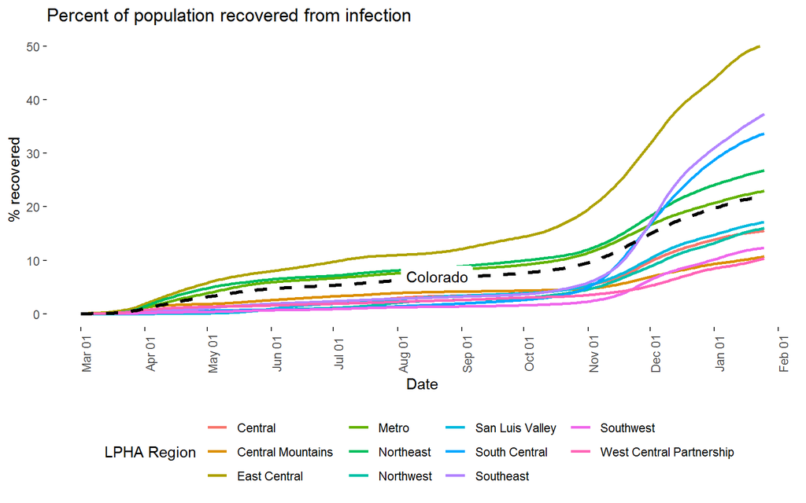

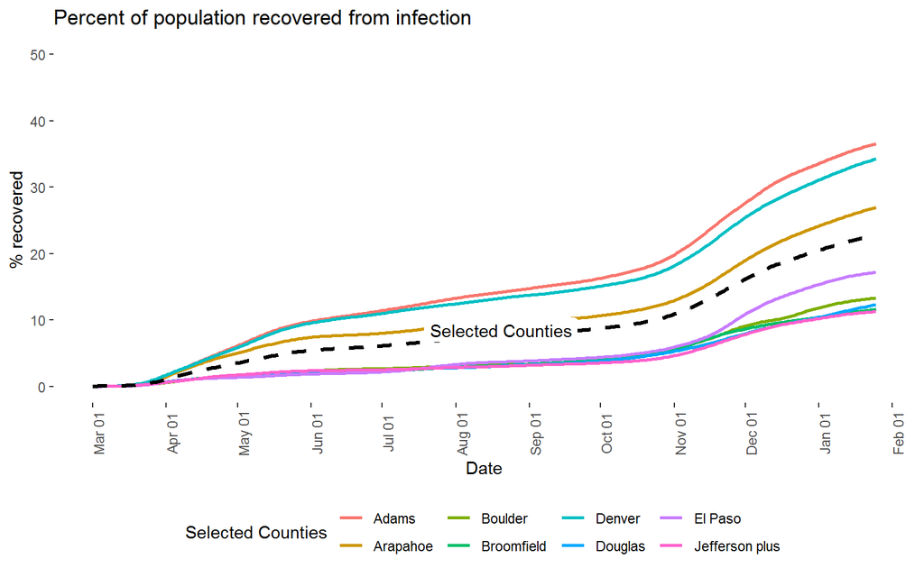

**Figure 3.** Estimated proportion of the population recovered to date for each of the 11 LPHA regions in Colorado (top) and each of the 8 selected counties and county clusters (bottom). Exposed proportion values estimated up to 01/25/2021. Black dashed line indicates mean of Colorado (top) and selected counties (bottom).

### **COVID-19 hospitalizations**

The figures below show the daily number of individuals hospitalized with COVID-19 from each region. Hospitalization data are from the COVID Patient Hospitalization Surveillance (COPHS) maintained by the Colorado Department of Public Health and the Environment (CDPHE). Each COVID-19 patient is assigned to a region based on their home zip code. COVID-19 hospitalizations are shown per 100,000 population to allow comparability across regions.

COVID-19 hospitalizations are a sensitive measure of SARS-CoV-2 transmission and are an important indicator of the severity of infections in a region. While many SARS-CoV-2 infections are not captured by state surveillance systems, we expect that almost all COVID-19 hospitalizations are identified.

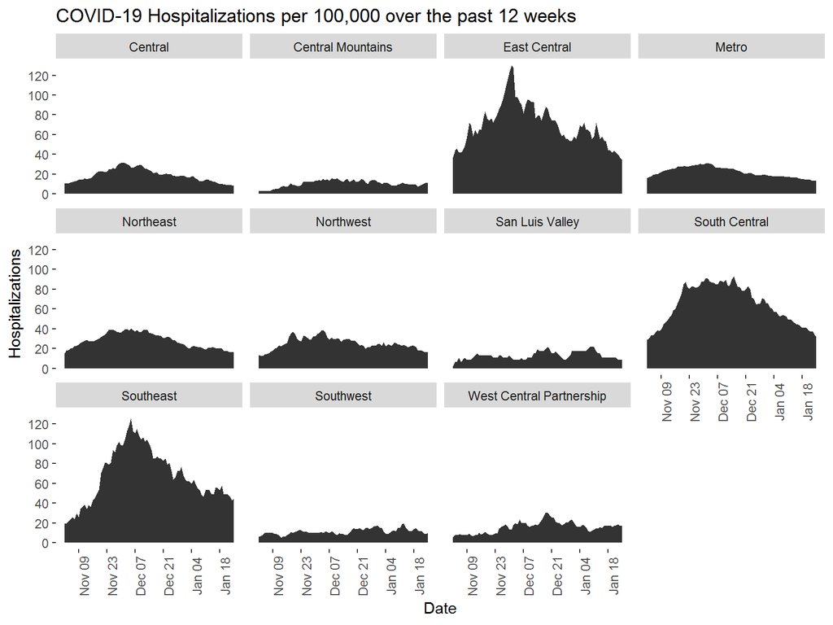

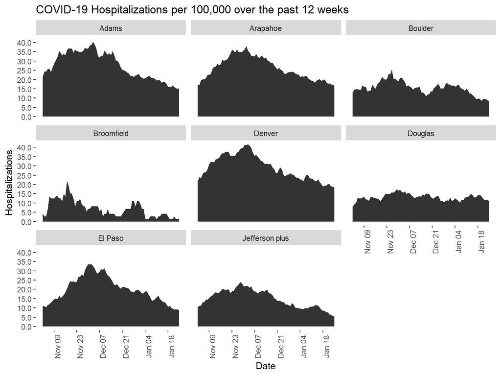

**Figure 4.** The daily number of people hospitalized with COVID-19 per capita for the 11 LPHA regions and the 8 selected counties and county clusters in Colorado over the past 12 weeks. Hospitalization data are from the COPHS hospital census data through 01/25/2021.

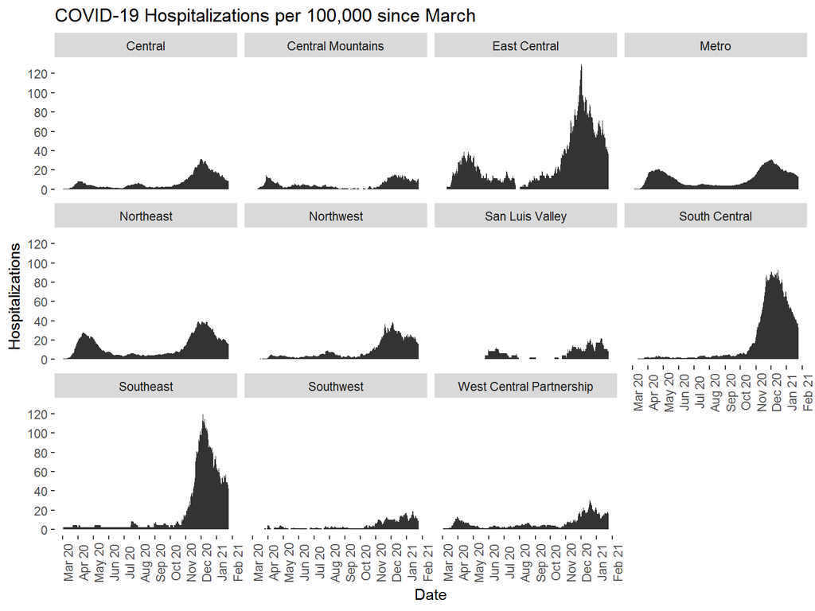

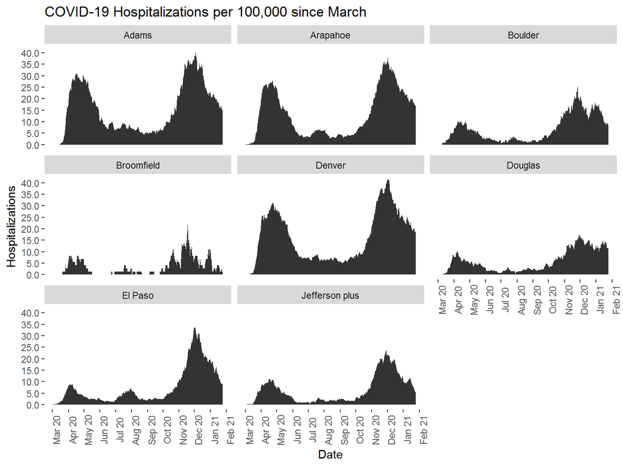

**Figure 5.** The daily number of people hospitalized with COVID-19 hospitalizations per capita for the 11 LPHA regions and the 8 selected counties and county clusters in Colorado since the first case was reported in March 2020. Hospitalization data are from the COPHS hospital census data through 01/25/2021.

### **Technical Summary**

Within the State of Colorado, as for other states, the spread of SARS-CoV-2 varies across the regions of the state, differing between urban and rural locations and resort and non-resort areas, for example. The modeling carried out by the Colorado COVID-19 Modeling Group was initiated at the state level providing a picture that does not give detail at the regional or county-level. Such detail is needed for public health planning and action, and many local public health agencies have asked for model simulations for their jurisdictions.

To provide the needed detail, the Modeling Group has developed regional -level models, using approaches similar to those for the overall Colorado model. The models are generated for the 11 local public health agency (LPHA) regions, which cover the full state and for selected counties. County-level estimation is possible for selected counties due to the large population size. In providing the results for regions within Colorado, the model results are subject to greater uncertainty than those for the entire state because there are fewer hospitalizations and cases in each region than in the state as a whole. Estimates are most uncertain for the regions with the smallest population size. Additional details about the methods used to generate regional estimates are described in the Technical Summary, below.

**Methods.** We use data on COVID-19 hospitalizations and reported cases, and a mathematical model of SARS-CoV-2 transmission to estimate the current state of infections in each region. The approach follows that used for the state-wide model, adapted for the smaller population sizes of the LPHA regions and selected counties. A full description of the model and estimation approaches are provided in the documentation, available [here](https://agb85.github.io/covid-19/SEIR%20Documentation.pdf). Prior modeling reports and documentation can be found [here](https://agb85.github.io/covid-19/). Briefly, the model is a deterministic age-structured susceptible, exposed, infected, recovered (SEIR) model. It has been parameterized to Colorado-specific data whenever possible - for example, the length of time a COVID-19 patient spends in the hospital varies by age and is based on data provided by Colorado hospitals. We use model fitting approaches to estimate the level of transmission control for each two-week period of the outbreak. Transmission control is estimated by fitting the model to hospitalization data for each region. In the four regions where population size is small (San Luis Valley, Southeast, Southwest, and West Central Partnership), we fit the model to reported case data, using information from the state-level model to infer the proportion of infections detected by state surveillance systems.

**Data Sources:** COVID-19 hospitalizations are obtained from COPHS reported through 01/29/2021.Due to lags in reporting, these data are cleaved 4 days prior such that hospitalizations through 01/25/2021 are used in modeling and shown in this report.

Case data are based on CEDRS through 01/30/2021. Due to lags in reporting, these data are cleaved ten days prior on 01/20/2021. Both data sources are provided by CDPHE.

**Limitations:** These estimates are based on the available data and the assumptions in the SEIR model. Assumptions in the model are based on Colorado data when available and the current scientific understanding of SARS-CoV-2, which is evolving rapidly. Estimated prevalence and the percent of the population recovered are sensitive to model assumptions, which include: the probability an infected individual will be symptomatic and require hospital care and the estimated length of hospital stay, which varies over time and by age. Estimates for the smallest regions are subject to greater uncertainty than larger regions and may experience greater variation from week to week due to the limited data available in these regions.

| Region | Population | Counties |
| --- | --- | --- |
| **LPHA Regions** |  |  |
| Central | 810,420 | Chaffee, El Paso, Lake, Park, Teller |
| Central Mountains | 182,689 | Eagle, Garfield, Grand, Pitkin, Summit |
| East Central | 43,032 | Cheyenne, Elbert, Kit Carson, Lincoln |
| Metro | 3,291,794 | Adams, Arapahoe, Boulder, Broomfield, Clear Creek, Denver, Douglas, Gilpin, Jefferson* |
| Northeast | 765,265 | Larimer, Logan, Morgan, Phillips, Sedgwick, Washington, Weld, Yuma |
| Northwest | 203,301 | Jackson, Mesa, Moffat, Rio Blanco, Routt |
| San Luis Valley | 46,472 | Alamosa, Conejos, Costilla, Rio Grande, Saguache |
| South Central | 243,196 | Custer, Fremont, Huerfano, Las Animas, Pueblo |
| Southeast | 46,938 | Baca, Bent, Crowley, Kiowa, Otero, Prowers |
| Southwest | 102,154 | Archuleta, Dolores, La Plata, Montezuma, San Juan |
| West Central Partnership | 106,839 | Delta, Gunnison, Hinsdale, Mineral, Montrose, Ouray, San Miguel |
| **Eight select counties** |  |  |
| Adams | 528,857 | Adams |
| Arapahoe | 664,988 | Arapahoe |
| Boulder | 330,978 | Boulder |
| Broomfield | 72,827 | Broomfield |
| Denver | 737,854 | Denver |
| Douglas | 354,331 | Douglas |
| El Paso | 737,354 | El Paso |
| Jefferson plus | 601,959 | Clear Creek, Gilpin, Jefferson |

**Table 2:** Description of the regions used in this report, including the 11 LPHA Regions. Population estimates are based on 2020 US Census Projections provided by the Colorado Demography Office.

*Clear Creek, Gilpin Counties and Jefferson counties are modeled as a single unit due to the small population of Clear Creek (9,379 residents) and Gilpin (5,924 residents) – populations too small to allow for stable estimation.

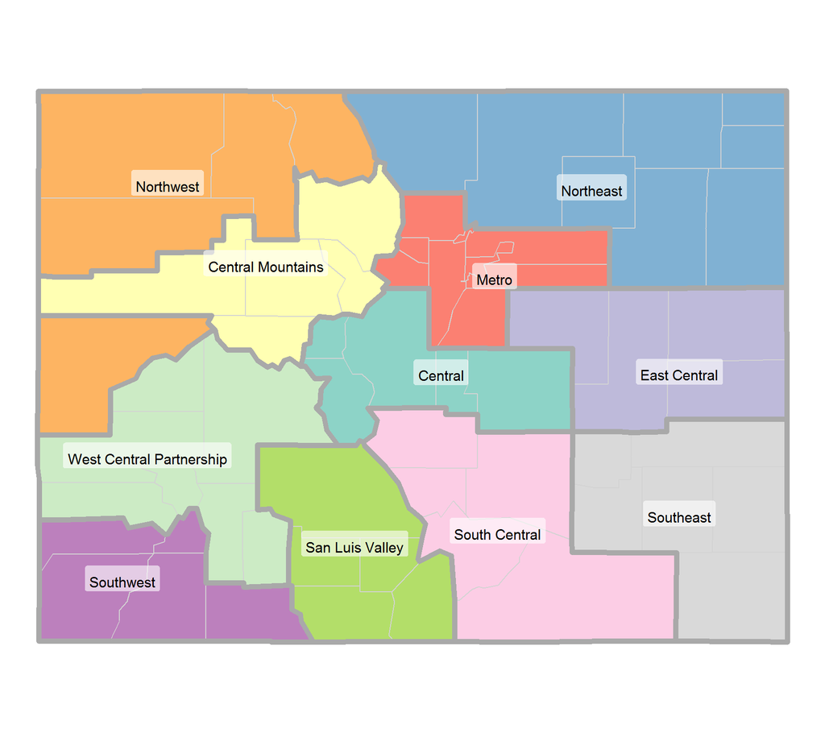

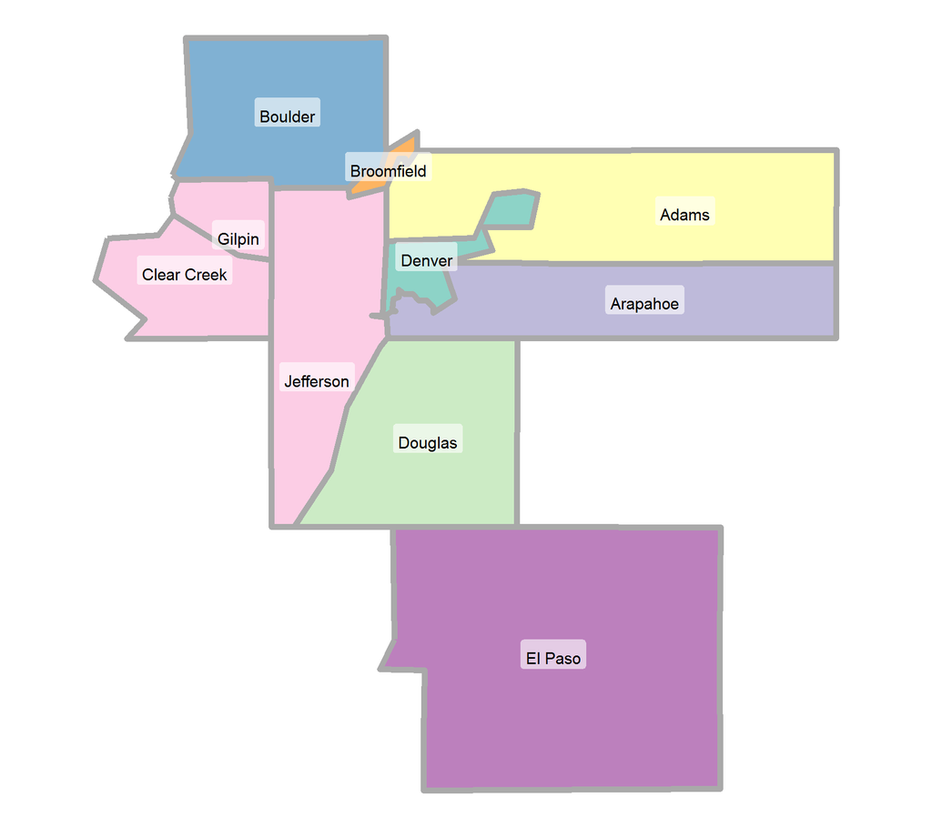

**Figure 6.** Map showing the 11 LPHA regions and 8 selected counties and county clusters for which estimates were generated.

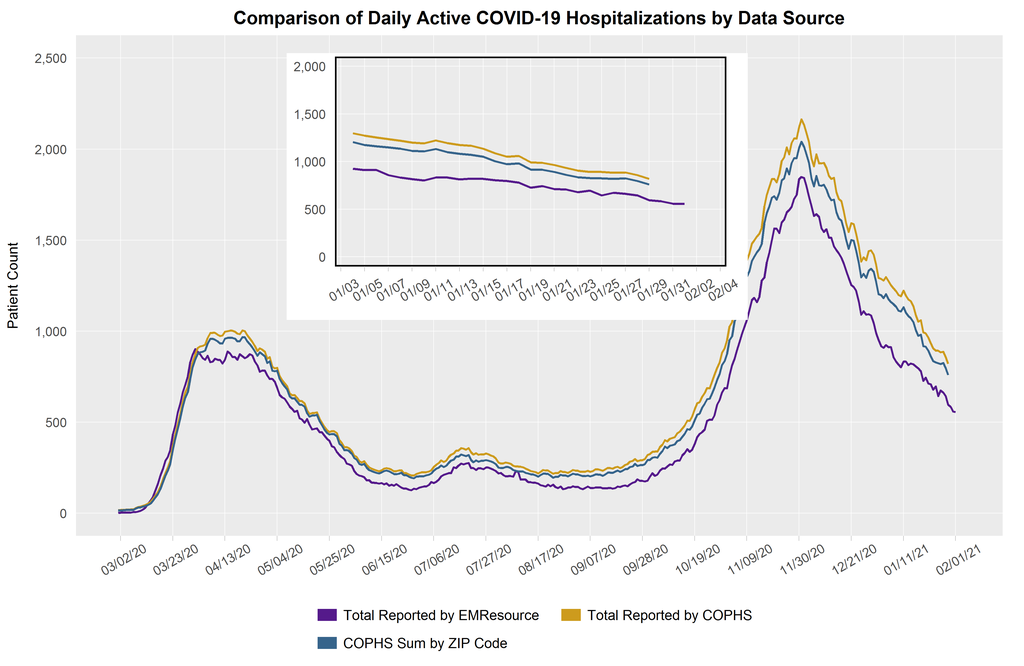

**Figure 7.** Comparison of daily active COVID-19 hospitalizations by data source.

*The COPHS data were updated in late December to include records that had previously been unreported. At present, the COPHS dataset now estimates more hospitalizations on a given day than EMResources. Because both datasources show the same trend (e.g., both increase and decrease together), this should not impact our estimates of the effective reproductive number. However, the addition of previously unreported records will lead estimates of infection prevalence to be higher in some regions on a given day than they were previously. We have updated the estimates of prevalence since March and these can be viewed in the region and county-specific estimates, allowing apples to apples comparison of changes in prevalence over time.